# Case Study 2: Employee Attrition

Catherine Ticzon

## Summary

This Rmarkdown file contains the supporting code for DDS Case Study 2 on employee attrition. The file is organized in chunks as follows:

1. Set Up
1. Data Cleaning
2. Exploratory Data Analysis (EDA)
3. Predicting Attrition with knn
4. Predicting Attrition with naive bayes
5. Predicting Attrition with linear regression
6. Predicting Salary with linear regression

## i. Set Up

```r
library(RCurl)
library(aws.s3)
library(tidyverse)
```

```r
library(dplyr)
library(ggplot2)

Sys.setenv("AWS_ACCESS_KEY_ID" = "AKIASVYTN36XDQAIQH4K",
           "AWS_SECRET_ACCESS_KEY" = "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",
           "AWS_DEFAULT_REGION" = "us-east-2")

# Need AWS_DEFAULT_REGION or else Error when loading in data from s3:
# Error in parse_aws_s3_response(r, Sig, verbose = verbose) :
# Moved Permanently (HTTP 301).

data <- s3read_using(FUN = read.csv,
                     bucket = "ddsproject1",
                     object = "CaseStudy2-data.csv")
```

## 1. Data Cleaning

- In this section, I make sure I do not have any missing values and I also change some of the variables to factor levels.

```r
sum(is.na(data)) # No missing data

# Check variables and change character values in columns to factor levels

table(data$Attrition)
data$Attrition = factor(data$Attrition, levels = c("No", "Yes"))

table(data$BusinessTravel)
data$BusinessTravel = factor(data$BusinessTravel, levels = c("Non-Travel", "Travel_Frequently",
                                                             "Travel_Rarely"))

table(data$Department)
data$Department = factor(data$Department, levels = c("Human Resources", "Research & Development", "Sales"))

table(data$EducationField)
data$EducationField = factor(data$EducationField, levels = c("Human Resources", "Life Sciences", "Marketing", "Medical", "Other", "Technical Degree"))

table(data$Gender)
data$Gender = factor(data$Gender, levels = c("Female", "Male"))

table(data$JobRole)
data$JobRole = factor(data$JobRole, levels = c("Healthcare Representative", "Human Resources", "Laboratory Technician", "Manager", "Manufacturing Director", "Research Director", "Research Scientist", "Sales Executive", "Sales Representative"))

table(data$MaritalStatus)
data$MaritalStatus = factor(data$MaritalStatus, levels = c("Divorced", "Married", "Single"))
```

## 2. Exploratory Data Analysis (EDA)

- In this section, I conduct and exploratory data analysis (EDA) to find trends in employee attrition
- I also conduct an EDA on the entire sample to compare to the trends in attrition in order to find variables that disproportionately make-up employee attrition
- This section includes several plots that are hidden in the knitted file

```r
# install.packages("ggthemes")
library(ggthemes)

# Explore variables of employees who left

# Create variable of those who left
quit <- data %>%
  filter(Attrition == "Yes")

# Summarize attrition by Gender
ggplot(quit, mapping=aes(x=Gender)) +
  geom_bar() +
  geom_text(stat='count', aes(label= ..count..), vjust= -1) +
  theme(axis.title.y = element_blank(),
        axis.title.x = element_blank(),
        axis.text.y = element_blank(),
        axis.ticks = element_blank(),
        panel.grid.major.y = element_blank(),
        panel.grid.major.x = element_blank(),
        panel.grid.minor.x = element_blank(),
        panel.grid.minor.y = element_blank(),
        panel.background = element_blank())
```

```r
# Summarize attrition by Age
attr_Age <- quit %>%
  group_by(Age) %>%
  summarise(count = n())

ggplot(attr_Age, mapping=aes(x=Age, y=count)) +
  geom_col()
```

```r
ggplot(attr_Age, mapping=aes(x=Age)) +
  geom_boxplot()
```

```r
# Summarize attrition by Job Role ----------------------------------------------
attr_JobRole <- data %>%
  group_by(JobRole, Attrition) %>%
  summarise(count = n()) %>%
  pivot_wider(names_from = Attrition, values_from = count, values_fill = 0)
```

```r
attr_JobRole_perc <- attr_JobRole %>%
  mutate(Yes_Perc = (Yes /140) * 100)

ggplot(attr_JobRole_perc, mapping=aes(x=JobRole, y=Yes_Perc)) +
  geom_col(fill="black", width= 0.5) +
  geom_text(aes(label = sprintf("%.1f%%", Yes_Perc), hjust=-.5)) +
    theme(axis.title.y = element_blank(),
          axis.title.x = element_blank(),
          axis.text.x = element_blank(),
          axis.ticks = element_blank(),
        panel.grid.major.y = element_blank(),
        panel.grid.major.x = element_blank(),
        panel.grid.minor.x = element_blank(),
        panel.grid.minor.y = element_blank(),
        panel.background = element_blank()) +
  coord_flip()
```

```r
# Summarize attrition by Travel
attr_Travel <- data %>%
  group_by(BusinessTravel, Attrition) %>%
  summarise(count = n()) %>%
  pivot_wider(names_from = Attrition, values_from = count, values_fill = 0)
# Summarize attrition by DailyRate
attr_DailyRate <- data %>%
  group_by(DailyRate, Attrition) %>%
  summarise(count = n()) %>%
  pivot_wider(names_from = Attrition, values_from = count, values_fill = 0)
# Create classes for DailyRate: Lower (100-500), Middle (500-1000), Upper (1000-1500)
breaks_DailyRate <- data %>%
  mutate(DailyRateClass = cut(data$DailyRate, breaks = c(100,500,1000,1500), labels = c("Lower", "Middle", "Upper")))

attr_breaks_DailyRate <- breaks_DailyRate %>%
  group_by(DailyRateClass, Attrition) %>%
  summarise(count = n()) %>%
  pivot_wider(names_from = Attrition, values_from = count, values_fill = 0)
```

```r
ggplot(data, mapping = aes(x=DailyRate, y=Attrition)) +
  geom_boxplot()
```

```r
# Summarize attrition by Department --------------------------------------------
attr_Department <- quit %>%
  group_by(Department) %>%
  summarise(count = n())

attr_Department_perc <- attr_Department %>%
  mutate(Department_perc = (count / 140) * 100)

ggplot(attr_Department_perc, mapping=aes(x=Department, y=Department_perc)) +
  geom_col(fill="black", width = 0.4) +
  geom_text(aes(label = sprintf("%.1f%%", Department_perc), vjust=2, color="white")) +
  theme(axis.title.y = element_blank(),
        axis.title.x = element_blank(),
        #axis.text.x = element_blank(),
        axis.text.y = element_blank(),
        axis.ticks = element_blank(),
        panel.grid.major.y = element_blank(),
        panel.grid.major.x = element_blank(),
        panel.grid.minor.x = element_blank(),
        panel.grid.minor.y = element_blank(),
        panel.background = element_blank()) +
   scale_color_identity()
```

```r
# Plot Attrition by Department next to whole sample

#prop_department <- full_join(attr_Department_perc, Department_perc, by="Department") %>%
#  rename("AttritionPerc"= "Department_perc",
#         "SamplePerc" = "perc")


#ggplot(prop_department, aes(x = Department)) +
  #geom_bar(aes(y = AttritionPerc, fill = "AttritionPerc"), position = "dodge", stat = "identity") +
  #geom_bar(aes(y = SamplePerc, fill = "SamplePerc"), position = "dodge", stat = "identity") +
  #scale_fill_manual(values = c("AttritionPerc" = "red", "SamplePerc" = "blue")) +
  #labs(x = "Department", y = "Percentage")


# Summarize attrition by DistanceFromHome
attr_Distance <- quit %>%
  group_by(DistanceFromHome) %>%
  summarise(count = n())

ggplot(attr_Distance, mapping=aes(x=DistanceFromHome, y=count)) +
  geom_col(fill="black") +
  labs(x = "Distance from Home (Units)", y = "Number of Employees") +
  #geom_text(aes(label = count), vjust = -0.3, color = "black") +
  theme(axis.title.y = element_blank(),
        #axis.title.x = element_blank(),
        #axis.text.x = element_blank(),
        #axis.text.y = element_blank(),
        #axis.ticks = element_blank(),
        panel.grid.major.y = element_line(color="light grey"),
        #panel.grid.major.x = element_blank(),
        panel.grid.minor.x = element_blank(),
        panel.grid.minor.y = element_blank(),
        panel.background = element_blank())
```

```r
# Summarize attrition by Education
attr_Education <- quit %>%
  group_by(Education) %>%
  summarise(count = n())

ggplot(attr_Education, mapping=aes(x=Education, y=count)) +
  geom_col(fill="light gray") +
  geom_text(aes(label = count), vjust = -0.3, color = "black") +
  labs(x="Education Level",
       y= "Number of Employees") +
  theme(axis.title.y = element_blank(),
        #axis.title.x = element_blank(),
        #axis.text.x = element_blank(),
        axis.text.y = element_blank(),
        axis.ticks = element_blank(),
        #panel.grid.major.y = element_line(color="light grey"),
        #panel.grid.major.x = element_blank(),
        panel.grid.minor.x = element_blank(),
        panel.grid.minor.y = element_blank(),
        panel.background = element_blank())
```

```r
# Summarize attrition by EducationField

attr_EducationField <- quit %>%
  group_by(EducationField) %>%
  summarise(count = n())

ggplot(attr_EducationField, mapping=aes(x=EducationField, y=count)) +
  geom_col()
```

```r
# Attriton by JobLevel----------------------------------------------------------
attr_JobLevel <- quit %>%
  group_by(JobLevel) %>%
  summarise(count = n())

ggplot(quit, mapping=aes(x=JobLevel)) +
  geom_bar()
```

```r
attr_JobLevel_perc <- attr_JobLevel %>%
  mutate(JobLevel_perc = (count / 140) * 100)

ggplot(attr_JobLevel_perc, mapping=aes(x=JobLevel, y=JobLevel_perc)) +
  geom_col(fill="light gray", width=.5) +
  geom_text(aes(label = sprintf("%.1f%%", JobLevel_perc))) +
  theme(axis.title.y = element_blank(),
        #axis.title.x = element_blank(),
        #axis.text.x = element_blank(),
        axis.text.y = element_blank(),
        axis.ticks = element_blank(),
        panel.grid.major.y = element_blank(),
        panel.grid.major.x = element_blank(),
        panel.grid.minor.x = element_blank(),
        panel.grid.minor.y = element_blank(),
        panel.background = element_blank()) +
  labs(x= "Job Level")
```

```r
# Attrition by EnvironmentSatisfaction------------------------------------------
attr_EnvSat <- quit %>%
  group_by(EnvironmentSatisfaction) %>%
  summarise(count=n()) %>%
  mutate(EnvSat_perc = (count/140) *100)

ggplot(attr_EnvSat, mapping=aes(x=EnvironmentSatisfaction, y=EnvSat_perc)) +
  geom_col(fill="light gray", width=.5) +
  geom_text(aes(label = sprintf("%.1f%%", EnvSat_perc))) +
  theme(axis.title.y = element_blank(),
        #axis.title.x = element_blank(),
        #axis.text.x = element_blank(),
        axis.text.y = element_blank(),
        axis.ticks = element_blank(),
        panel.grid.major.y = element_blank(),
        panel.grid.major.x = element_blank(),
        panel.grid.minor.x = element_blank(),
        panel.grid.minor.y = element_blank(),
        panel.background = element_blank()) +
  labs(x="Environment Satisfaction")
```

```r
# Attrition by WorkLifeBalance
attr_WorkLifeBalance <- quit %>%
  group_by(WorkLifeBalance) %>%
  summarise(count=n()) %>%
  mutate(perc = (count/140) *100)

ggplot(attr_WorkLifeBalance, mapping=aes(x=WorkLifeBalance, y=perc)) +
  geom_col()
```

```r
# Attrition by RelationshipSatisfaction
attr_RelationshipSat <- quit %>%
  group_by(RelationshipSatisfaction) %>%
  summarise(count=n()) %>%
  mutate(perc = (count/140) *100)

ggplot(attr_RelationshipSat, mapping=aes(x=RelationshipSatisfaction, y=perc)) +
  geom_col()
```

```r
# Attrition by JobSatisfaction
attr_JobSat <- quit %>%
  group_by(JobSatisfaction) %>%
  summarise(count=n()) %>%
  mutate(perc = (count/140) *100)

ggplot(attr_JobSat, mapping=aes(x=JobSatisfaction, y=perc)) +
  geom_col()
```

```r
# Attrition by PerformanceRating
attr_PerfRate <- quit %>%
  group_by(PerformanceRating) %>%
  summarise(count=n()) %>%
  mutate(perc = (count/140) *100)

ggplot(attr_PerfRate, mapping=aes(x=PerformanceRating, y=perc)) +
  geom_col()
```

```r
# Attrition by PercentSalaryHike
attr_PercSalHike <- quit %>%
  group_by(PercentSalaryHike) %>%
  summarise(count=n()) %>%
  mutate(perc = (count/140) *100)

ggplot(attr_PercSalHike, mapping=aes(x=PercentSalaryHike, y=perc)) +
  geom_col()
```

```r
# Attrition by JobInvolvement--------------------------------------------------
attr_JobInvolv <- quit %>%
  group_by(JobInvolvement) %>%
  summarise(count=n()) %>%
  mutate(perc = (count/140) *100)

ggplot(attr_JobInvolv, mapping=aes(x=JobInvolvement, y=perc)) +
  geom_col()
```

```r
# Attrition by YearsSinceLastPromotion
attr_YrsPromo <- quit %>%
  group_by(YearsSinceLastPromotion) %>%
  summarise(count=n()) %>%
  mutate(perc = (count/140) *100)

ggplot(attr_YrsPromo, mapping=aes(x=YearsSinceLastPromotion, y=perc)) +
  geom_col()
```

```r
# Attrition by TrainingTimesLastYear
attr_Training <- quit %>%
  group_by(TrainingTimesLastYear) %>%
  summarise(count=n()) %>%
  mutate(perc = (count/140) *100)

ggplot(attr_Training, mapping=aes(x=TrainingTimesLastYear, y=perc)) +
  geom_col()
```

```r
# Attrition by MonthlyIncome
attr_MonthInc <- quit %>%
  group_by(MonthlyIncome) %>%
  summarise(count=n()) %>%
  mutate(perc = (count/140) *100)

ggplot(attr_MonthInc, mapping=aes(x=MonthlyIncome, y=perc)) +
  geom_jitter()
```

```r
ggplot(attr_MonthInc, mapping=aes(x=MonthlyIncome, y=count)) +
  geom_jitter()
```

```r
# Explore variables of entire sample =======================================

# Age
ggplot(data, mapping=aes(x=Age)) +
  geom_histogram()
# Gender
ggplot(data, mapping=aes(x=Gender, fill=Gender)) +
  geom_bar() +
  geom_text(stat='count', aes(label= ..count..), vjust= -1) +
  scale_fill_manual(values = c("#000000", "#c9c9c9")) +
  theme(axis.title.y = element_blank(),
        panel.grid.major.y = element_blank(),
        panel.grid.major.x = element_blank(),
        panel.grid.minor.x = element_blank(),
        panel.grid.minor.y = element_blank(),
        panel.background = element_blank())
```

```r
# Job Roles --------------------------------------------------------------------
JobRole <- data %>%
  group_by(JobRole) %>%
  summarise(count = n())

JobRole_perc <- JobRole %>%
  mutate(JobRolePerc = (count /870) * 100)

# Department
Department <- data %>%
  group_by(Department) %>%
  summarise(count = n())

Department_perc <- Department %>%
  mutate(perc = (count /870) * 100)

ggplot(Department_perc, mapping=aes(x=Department, y=perc)) +
  geom_col(fill="light grey", width=.4) +
  geom_text(aes(label = sprintf("%.1f%%", perc), vjust= 1.5)) +
  theme(axis.title.y = element_blank(),
        axis.title.x = element_blank(),
        #axis.text.x = element_blank(),
        axis.text.y = element_blank(),
        axis.ticks = element_blank(),
        panel.grid.major.y = element_blank(),
        panel.grid.major.x = element_blank(),
        panel.grid.minor.x = element_blank(),
        panel.grid.minor.y = element_blank(),
        panel.background = element_blank())
```

```r
# Plot Job Role by Count
ggplot(data, mapping=aes(x=JobRole)) +
  geom_bar(fill = "light grey") +
  geom_text(stat='count', aes(label= ..count..), hjust= -1) +
  theme(axis.title.y = element_blank(),
        axis.title.x = element_blank(),
        axis.text.x = element_blank(),
        axis.ticks = element_blank(),
        panel.grid.major.y = element_blank(),
        panel.grid.major.x = element_blank(),
        panel.grid.minor.x = element_blank(),
        panel.grid.minor.y = element_blank(),
        panel.background = element_blank()) +
  coord_flip()
```

```r
# Plot Job Role by Percentage
ggplot(JobRole_perc, mapping=aes(x=JobRole, y=JobRolePerc)) +
  geom_col(fill = "light grey", width= 0.5) +
  geom_text(aes(label = sprintf("%.1f%%", JobRolePerc), hjust=1.5)) +
  theme(axis.title.y = element_blank(),
        axis.title.x = element_blank(),
        axis.text.x = element_blank(),
        axis.ticks = element_blank(),
        panel.grid.major.y = element_blank(),
        panel.grid.major.x = element_blank(),
        panel.grid.minor.x = element_blank(),
        panel.grid.minor.y = element_blank(),
        panel.background = element_blank()) +
  coord_flip()
```

```r
# Education
ggplot(data, mapping=aes(Education)) +
  geom_bar()
```

```r
# Education Field
ggplot(data, mapping=aes(EducationField)) +
  geom_bar()
```

```r
# Job Level---------------------------------------------------------------------
JobLevel <- data %>%
  group_by(JobLevel) %>%
  summarise(count = n()) %>%
  mutate(JobLevel_perc = (count/870)*100)

ggplot(JobLevel, mapping=aes(x=JobLevel, y=JobLevel_perc)) +
  geom_col(fill="light gray", width=.5) +
  geom_text(aes(label = sprintf("%.1f%%", JobLevel_perc))) +
  theme(axis.title.y = element_blank(),
        #axis.title.x = element_blank(),
        #axis.text.x = element_blank(),
        axis.text.y = element_blank(),
        axis.ticks = element_blank(),
        panel.grid.major.y = element_blank(),
        panel.grid.major.x = element_blank(),
        panel.grid.minor.x = element_blank(),
        panel.grid.minor.y = element_blank(),
        panel.background = element_blank()) +
  labs(x= "Job Level")
```

```r
# Environment Satisfaction------------------------------------------------------
EnvSat <- data %>%
  group_by(EnvironmentSatisfaction) %>%
  summarise(count=n()) %>%
  mutate(EnvSat_perc = (count/870) *100)

ggplot(EnvSat, mapping=aes(x=EnvironmentSatisfaction, y=EnvSat_perc)) +
  geom_col(fill="light gray", width=.5) +
  geom_text(aes(label = sprintf("%.1f%%", EnvSat_perc))) +
  theme(axis.title.y = element_blank(),
        #axis.title.x = element_blank(),
        #axis.text.x = element_blank(),
        axis.text.y = element_blank(),
        axis.ticks = element_blank(),
        panel.grid.major.y = element_blank(),
        panel.grid.major.x = element_blank(),
        panel.grid.minor.x = element_blank(),
        panel.grid.minor.y = element_blank(),
        panel.background = element_blank()) +
  labs(x="Environment Satisfaction")
```

```r
# WorkLifeBalance
WorkLifeBalance <- data %>%
  group_by(WorkLifeBalance) %>%
  summarise(count=n()) %>%
  mutate(perc = (count/870) *100)

ggplot(WorkLifeBalance, mapping=aes(x=WorkLifeBalance, y=perc)) +
  geom_col()
```

```r
# RelationshipSatisfaction
RelationshipSat <- data %>%
  group_by(RelationshipSatisfaction) %>%
  summarise(count=n()) %>%
  mutate(perc = (count/870) *100)

ggplot(RelationshipSat, mapping=aes(x=RelationshipSatisfaction, y=perc)) +
  geom_col()
```

```r
# JobSatisfaction
JobSat <- data %>%
  group_by(JobSatisfaction) %>%
  summarise(count=n()) %>%
  mutate(perc = (count/870) *100)

ggplot(JobSat, mapping=aes(x=JobSatisfaction, y=perc)) +
  geom_col()
```

```r
# PerformanceRating
PerfRate <- data %>%
  group_by(PerformanceRating) %>%
  summarise(count=n()) %>%
  mutate(perc = (count/870) *100)

ggplot(PerfRate, mapping=aes(x=PerformanceRating, y=perc)) +
  geom_col()
```

```r
# PercentSalaryHike
PercSalHike <- data %>%
  group_by(PercentSalaryHike) %>%
  summarise(count=n()) %>%
  mutate(perc = (count/870) *100)

ggplot(PercSalHike, mapping=aes(x=PercentSalaryHike, y=perc)) +
  geom_col()
```

```r
# JobInvolvement ---------------------------------------------------------------
JobInvolv <- data %>%
  group_by(JobInvolvement) %>%
  summarise(count=n()) %>%
  mutate(perc = (count/870) *100)

ggplot(JobInvolv, mapping=aes(x=JobInvolvement, y=perc)) +
  geom_col()
```

```r
# YearsSinceLastPromotion
YrsPromo <- data %>%
  group_by(YearsSinceLastPromotion) %>%
  summarise(count=n()) %>%
  mutate(perc = (count/870) *100)

ggplot(YrsPromo, mapping=aes(x=YearsSinceLastPromotion, y=perc)) +
  geom_col()
```

```r
# TrainingTimesLastYear
Training <- data %>%
  group_by(TrainingTimesLastYear) %>%
  summarise(count=n()) %>%
  mutate(perc = (count/870) *100)

ggplot(Training, mapping=aes(x=TrainingTimesLastYear, y=perc)) +
  geom_col()
```

```r
# MonthlyIncome
MonthInc <- data %>%
  group_by(MonthlyIncome) %>%
  summarise(count=n()) %>%
  mutate(perc = (count/870) *100)

ggplot(MonthInc, mapping=aes(x=MonthlyIncome, y=perc)) +
  geom_jitter()
```

```r
ggplot(MonthInc, mapping=aes(x=MonthlyIncome, y=count)) +
  geom_jitter()
```

```r
# Misc plotting and EDA ------------------------------------------------------


# group_by JobRole

jr_income <- data %>%
  group_by(JobRole) %>%
  summarise(mean_income = mean(MonthlyIncome))

jr_jobinvolv <- data %>%
  group_by(JobRole) %>%
  summarise(mean_jobinvolv = mean(JobInvolvement))

jr_envsat <- data %>%
  group_by(JobRole) %>%
  summarise(mean_envsat = mean(EnvironmentSatisfaction))

# Boxplot of JobLevel by JobRole
ggplot(data, mapping=aes(x=JobRole, y=JobLevel)) +
  geom_boxplot() +
  labs(title="Boxplot of Job Level by Job Role",
       subtitle="n=870",
       y="Job Level") +
  theme(axis.title.y = element_blank(),
        #axis.title.x = element_blank(),
        #axis.text.x = element_text(angle=90, hjust =.95, vjust= .2),
        axis.ticks = element_blank(),
        panel.grid.major.y = element_line(color="grey"),
        panel.background = element_blank()) +
  coord_flip()
```

```r
jr_promo <- data %>%
  group_by(JobRole) %>%
  summarise(mean_promo = mean(YearsSinceLastPromotion))

ggplot(data, aes(x=JobRole, y=YearsAtCompany)) +
  geom_boxplot() +
  coord_flip() +
  theme(axis.title.y = element_blank(),
        panel.grid.major.y = element_blank(),
        panel.grid.major.x = element_line(color="grey"),
        panel.grid.minor.x = element_line(color="grey"),
        #panel.grid.minor.y = element_line(color="grey"),
        panel.background = element_blank()) +
  labs(title= "Boxplot of Number of Years at Company by Job Role",
       subtitle ="n=870",
        x="Job Role", y="Number of Years at Company")
```

## 3. Analysis of Variables Related to Attrition

```r
# Model JobLevel ~ Attrition
model_JobLevel <- lm(JobLevel ~ Attrition, data = data)
summary(model_JobLevel)
```

```
##
## Call:
## lm(formula = JobLevel ~ Attrition, data = data)
##
## Residuals:
##     Min      1Q  Median      3Q     Max
## -1.1164 -1.1164 -0.1164  0.8836  3.3643
##
## Coefficients:
##              Estimate Std. Error t value Pr(>|t|)
## (Intercept)   2.11644    0.03984  53.129  < 2e-16 ***
## AttritionYes -0.48072    0.09930  -4.841 1.53e-06 ***
## ---
## Signif. codes:  0 '***' 0.001 '**' 0.01 '*' 0.05 '.' 0.1 ' ' 1
##
## Residual standard error: 1.076 on 868 degrees of freedom
## Multiple R-squared:  0.02629,    Adjusted R-squared:  0.02517
## F-statistic: 23.43 on 1 and 868 DF,  p-value: 1.53e-06
```

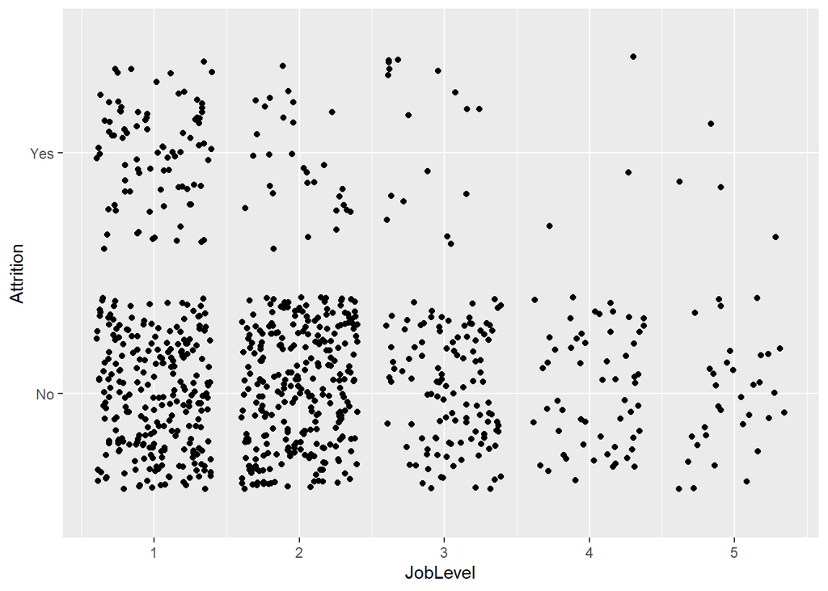

```r
ggplot(data, aes(x=JobLevel, y=Attrition)) +
  geom_jitter()
```

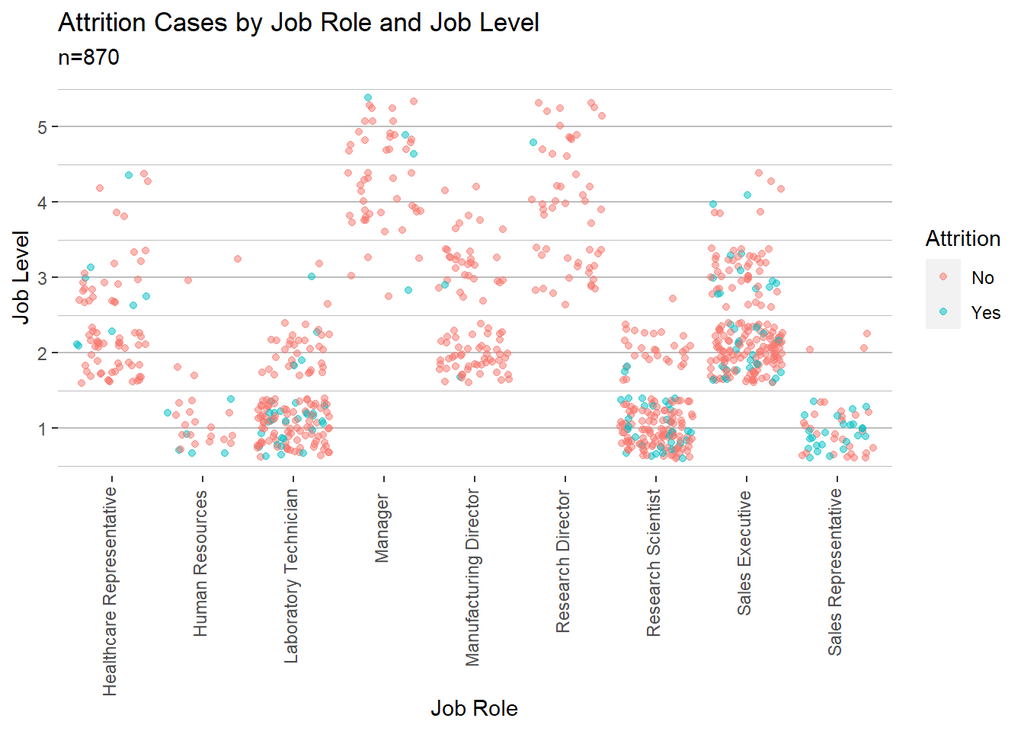

```r
# Plot JobLevel, Job Role, and Attrition

data %>% ggplot(aes(x=JobRole, y = JobLevel, color=Attrition)) +
  geom_jitter(alpha = .5) +
  theme(axis.text.x = element_text(angle=90, hjust =.95, vjust= .2),
        panel.grid.major.y = element_line(color="grey"),
        panel.grid.major.x = element_blank(),
        panel.grid.minor.x = element_line(color="grey"),
        panel.grid.minor.y = element_line(color="grey"),
        panel.background = element_blank()) +
  labs(title= "Attrition Cases by Job Role and Job Level",
       subtitle ="n=870",
        x="Job Role", y="Job Level")
```

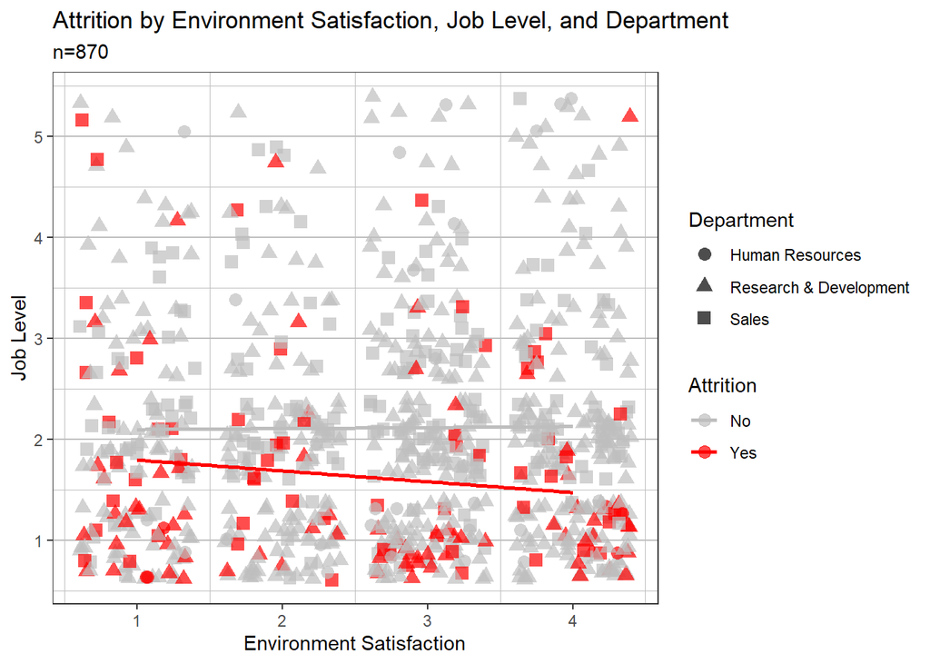

```r
# Plot Environment Satisfaction, Job Level, Departmen ~ Attrition

theme_set(theme_bw())  # pre-set the bw theme.
g <- ggplot(data, aes(EnvironmentSatisfaction, JobLevel)) +
  labs(subtitle="n=870",
       title="Attrition by Environment Satisfaction, Job Level, and Department",
       x="Environment Satisfaction",
       y="Job Level")

g + geom_jitter(aes(col=Attrition, shape = Department), size=3, alpha=.7) +
  geom_smooth(aes(col=Attrition), method="lm", se=F) +
  scale_color_manual(values = c("No" = "grey", "Yes" = "red")) +
  theme(panel.grid.major.y = element_line(color="grey"),
        panel.grid.major.x = element_blank(),
        panel.grid.minor.x = element_line(color="grey"),
        panel.grid.minor.y = element_line(color="grey"),
        panel.background = element_blank())
```

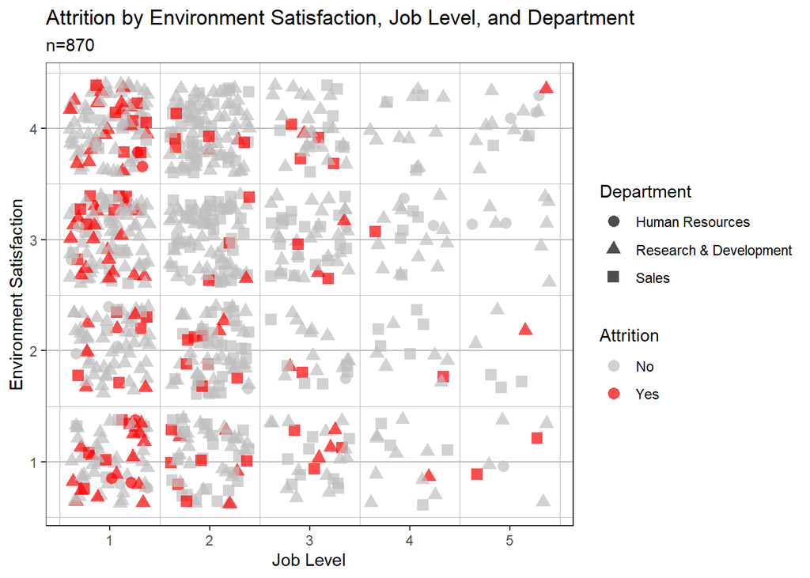

```r
# Switch x and y axis

theme_set(theme_bw())  # pre-set the bw theme.
h <- ggplot(data, aes(JobLevel, EnvironmentSatisfaction)) +
  labs(subtitle="n=870",
       title="Attrition by Environment Satisfaction, Job Level, and Department",
       x="Job Level",
       y="Environment Satisfaction")

h + geom_jitter(aes(col=Attrition, shape = Department), size=3, alpha=.7) +
  #geom_smooth(aes(col=Attrition), method="lm", se=F) +
  scale_color_manual(values = c("No" = "grey", "Yes" = "red")) +
  theme(panel.grid.major.y = element_line(color="grey"),
        panel.grid.major.x = element_blank(),
        panel.grid.minor.x = element_line(color="grey"),
        panel.grid.minor.y = element_line(color="grey"),
        panel.background = element_blank())
```

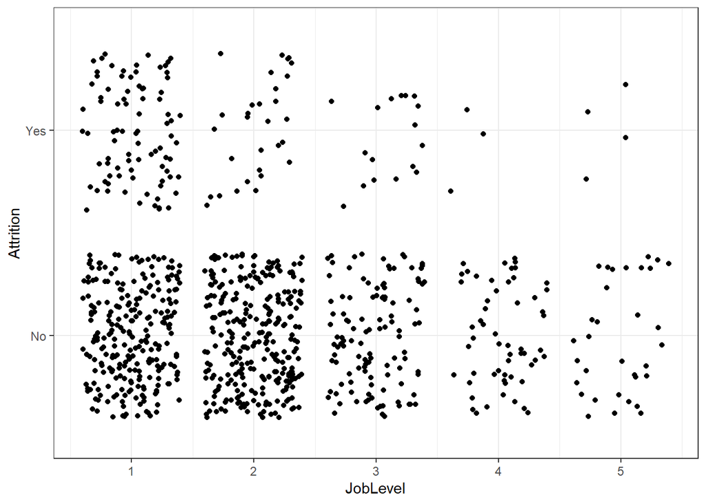

```r
# Model Job Role + Job Satisfaction  ~ Attrition

ggplot(data, aes(x=JobLevel, y=Attrition)) +
  geom_jitter()
```

## 4. Predicting Attrition with knn

```r
library(class)
library(caret)
# Load in the set that will be used as the final test set/competition set
attrition_comp <- s3read_using(FUN = read.csv,
                     bucket = "ddsproject1",
                     object = "CaseStudy2CompSet No Attrition.csv")

# Change Attrition to numeric levels (Yes=1 / No=0)
data2 <- data %>%
  mutate(Attrition = recode(Attrition, Yes = "1", No = '0'))

# Create training indices for knn model
set.seed(1)
splitPerc = .7

trainInd_attr = sample(1:dim(data2)[1], round(splitPerc * dim(data2)[1]))
train_attr = data2[trainInd_attr,]
test_attr = data2[-trainInd_attr,]

# Model 2: JobLevel and EnvironmentSatisfaction --------------------------------
train2 <- train_attr %>%
  select(JobLevel, EnvironmentSatisfaction, Attrition)

test2 <- test_attr %>%
  select(JobLevel,EnvironmentSatisfaction, Attrition)

knn_model2 = knn(train2[,c(1,2)], test2[,c(1,2)], train2$Attrition, k=5, prob=TRUE)
confusionMatrix(table(knn_model2, test2$Attrition))
```

```
## Confusion Matrix and Statistics
##
##
## knn_model2   0   1
##          0 220  41
##          1   0   0
##
##                Accuracy : 0.8429
##                  95% CI : (0.793, 0.8849)
##     No Information Rate : 0.8429
##     P-Value [Acc > NIR] : 0.5416
##
##                   Kappa : 0
##
##  Mcnemar's Test P-Value : 4.185e-10
##
##             Sensitivity : 1.0000
##             Specificity : 0.0000
##          Pos Pred Value : 0.8429
##          Neg Pred Value :    NaN
##              Prevalence : 0.8429
##          Detection Rate : 0.8429
##    Detection Prevalence : 1.0000
##       Balanced Accuracy : 0.5000
##
##        'Positive' Class : 0
##
```

```r
# Change Threshold
probs = ifelse(knn_model2 == "1", attributes(knn_model2)$prob, 1- attributes(knn_model2)$prob)

# New Threshold
summary(data2$Attrition)
```

```
##   0   1
## 730 140
```

```r
# 140/870 = 16% left

NewClass = ifelse(probs > .14, "1", "0")
table(NewClass, test2[,3])
```

```
##
## NewClass   0   1
##        0 122  15
##        1  98  26
```

```r
CM = confusionMatrix(table(NewClass, test2[,3]), mode = "everything")
CM
```

```
## Confusion Matrix and Statistics
##
##
## NewClass   0   1
##        0 122  15
##        1  98  26
##
##                Accuracy : 0.567
##                  95% CI : (0.5045, 0.628)
##     No Information Rate : 0.8429
##     P-Value [Acc > NIR] : 1
##
##                   Kappa : 0.1035
##
##  Mcnemar's Test P-Value : 1.22e-14
##
##             Sensitivity : 0.5545
##             Specificity : 0.6341
##          Pos Pred Value : 0.8905
##          Neg Pred Value : 0.2097
##               Precision : 0.8905
##                  Recall : 0.5545
##                      F1 : 0.6835
##              Prevalence : 0.8429
##          Detection Rate : 0.4674
##    Detection Prevalence : 0.5249
##       Balanced Accuracy : 0.5943
##
##        'Positive' Class : 0
##
```

```r
# Model 3: JobInvolvement and RelationshipSatisfaction -------------------------
train3 <- train_attr %>%
  select(JobInvolvement, RelationshipSatisfaction, Attrition)

test3 <- test_attr %>%
  select(JobInvolvement, RelationshipSatisfaction, Attrition)

knn_model3 = knn(train3[,c(1,2)], test3[,c(1,2)], train3$Attrition, k=5, prob=TRUE)

confusionMatrix(table(knn_model3, test3$Attrition))
```

```
## Confusion Matrix and Statistics
##
##
## knn_model3   0   1
##          0 218  39
##          1   2   2
##
##                Accuracy : 0.8429
##                  95% CI : (0.793, 0.8849)
##     No Information Rate : 0.8429
##     P-Value [Acc > NIR] : 0.5416
##
##                   Kappa : 0.0627
##
##  Mcnemar's Test P-Value : 1.885e-08
##
##             Sensitivity : 0.99091
##             Specificity : 0.04878
##          Pos Pred Value : 0.84825
##          Neg Pred Value : 0.50000
##              Prevalence : 0.84291
##          Detection Rate : 0.83525
##    Detection Prevalence : 0.98467
##       Balanced Accuracy : 0.51984
##
##        'Positive' Class : 0
##
```

```r
# Change threshold
probs3 = ifelse(knn_model3 == "1", attributes(knn_model3)$prob, 1- attributes(knn_model3)$prob)

#New Threshold
summary(data2$Attrition)
```

```
##   0   1
## 730 140
```

```r
# 140/870 = 16% left

NewClass3 = ifelse(probs3 > .17, "1", "0")
table(NewClass3, test3[,3])
```

```
##
## NewClass3   0   1
##         0 136  19
##         1  84  22
```

```r
CM3 = confusionMatrix(table(NewClass3, test3[,3]), mode = "everything")
CM3
```

```
## Confusion Matrix and Statistics
##
##
## NewClass3   0   1
##         0 136  19
##         1  84  22
##
##                Accuracy : 0.6054
##                  95% CI : (0.5432, 0.6651)
##     No Information Rate : 0.8429
##     P-Value [Acc > NIR] : 1
##
##                   Kappa : 0.0941
##
##  Mcnemar's Test P-Value : 2.861e-10
##
##             Sensitivity : 0.6182
##             Specificity : 0.5366
##          Pos Pred Value : 0.8774
##          Neg Pred Value : 0.2075
##               Precision : 0.8774
##                  Recall : 0.6182
##                      F1 : 0.7253
##              Prevalence : 0.8429
##          Detection Rate : 0.5211
##    Detection Prevalence : 0.5939
##       Balanced Accuracy : 0.5774
##
##        'Positive' Class : 0
##
```

```r
# Model 4: JobInvolvement and Age ----------------------------------------------
train4 <- train_attr %>%
  select(JobInvolvement, Age, Attrition)

test4 <- test_attr %>%
  select(JobInvolvement, Age, Attrition)

knn_model4 = knn(train4[,c(1,2)], test4[,c(1,2)], train4$Attrition, k=5, prob=TRUE)

confusionMatrix(table(knn_model4, test4$Attrition))
```

```
## Confusion Matrix and Statistics
##
##
## knn_model4   0   1
##          0 212  38
##          1   8   3
##
##                Accuracy : 0.8238
##                  95% CI : (0.772, 0.868)
##     No Information Rate : 0.8429
##     P-Value [Acc > NIR] : 0.826
##
##                   Kappa : 0.0524
##
##  Mcnemar's Test P-Value : 1.904e-05
##
##             Sensitivity : 0.96364
##             Specificity : 0.07317
##          Pos Pred Value : 0.84800
##          Neg Pred Value : 0.27273
##              Prevalence : 0.84291
##          Detection Rate : 0.81226
##    Detection Prevalence : 0.95785
##       Balanced Accuracy : 0.51840
##
##        'Positive' Class : 0
##
```

```r
# Change threshold
probs4 = ifelse(knn_model4 == "1", attributes(knn_model4)$prob, 1- attributes(knn_model4)$prob)

#New Threshold
summary(data2$Attrition)
```

```
##   0   1
## 730 140
```

```r
# 140/870 = 16% left

NewClass4 = ifelse(probs4 > .1, "1", "0")
table(NewClass4, test4[,3])
```

```
##
## NewClass4   0   1
##         0  96  13
##         1 124  28
```

```r
CM4 = confusionMatrix(table(NewClass4, test4[,3]), mode = "everything")
CM4
```

```
## Confusion Matrix and Statistics
##
##
## NewClass4   0   1
##         0  96  13
##         1 124  28
##
##                Accuracy : 0.4751
##                  95% CI : (0.4132, 0.5376)
##     No Information Rate : 0.8429
##     P-Value [Acc > NIR] : 1
##
##                   Kappa : 0.0568
##
##  Mcnemar's Test P-Value : <2e-16
##
##             Sensitivity : 0.4364
##             Specificity : 0.6829
##          Pos Pred Value : 0.8807
##          Neg Pred Value : 0.1842
##               Precision : 0.8807
##                  Recall : 0.4364
##                      F1 : 0.5836
##              Prevalence : 0.8429
##          Detection Rate : 0.3678
##    Detection Prevalence : 0.4176
##       Balanced Accuracy : 0.5596
##
##        'Positive' Class : 0
##
```

```r
# Model 5: JobLevel and NumCompaniesWorked -------------------------------------
train5 <- train_attr %>%
  select(JobLevel, NumCompaniesWorked, Attrition)

test5 <- test_attr %>%
  select(JobLevel, NumCompaniesWorked, Attrition)

knn_model5 = knn(train5[,c(1,2)], test5[,c(1,2)], train5$Attrition, k=5, prob=TRUE)

confusionMatrix(table(knn_model5, test5$Attrition))
```

```
## Confusion Matrix and Statistics
##
##
## knn_model5   0   1
##          0 215  40
##          1   5   1
##
##                Accuracy : 0.8276
##                  95% CI : (0.7762, 0.8714)
##     No Information Rate : 0.8429
##     P-Value [Acc > NIR] : 0.7804
##
##                   Kappa : 0.0025
##
##  Mcnemar's Test P-Value : 4.011e-07
##
##             Sensitivity : 0.97727
##             Specificity : 0.02439
##          Pos Pred Value : 0.84314
##          Neg Pred Value : 0.16667
##              Prevalence : 0.84291
##          Detection Rate : 0.82375
##    Detection Prevalence : 0.97701
##       Balanced Accuracy : 0.50083
##
##        'Positive' Class : 0
##
```

```r
# Change threshold
probs5 = ifelse(knn_model5 == "1", attributes(knn_model5)$prob, 1- attributes(knn_model5)$prob)

#New Threshold
summary(data2$Attrition)
```

```
##   0   1
## 730 140
```

```r
# 140/870 = 16% left

NewClass5 = ifelse(probs5 > .16, "1", "0")
table(NewClass5, test5[,3])
```

```
##
## NewClass5   0   1
##         0 119  13
##         1 101  28
```

```r
CM5= confusionMatrix(table(NewClass5, test5[,3]), mode = "everything")
CM5
```

```
## Confusion Matrix and Statistics
##
##
## NewClass5   0   1
##         0 119  13
##         1 101  28
##
##                Accuracy : 0.5632
##                  95% CI : (0.5007, 0.6243)
##     No Information Rate : 0.8429
##     P-Value [Acc > NIR] : 1
##
##                   Kappa : 0.1195
##
##  Mcnemar's Test P-Value : 3.691e-16
##
##             Sensitivity : 0.5409
##             Specificity : 0.6829
##          Pos Pred Value : 0.9015
##          Neg Pred Value : 0.2171
##               Precision : 0.9015
##                  Recall : 0.5409
##                      F1 : 0.6761
##              Prevalence : 0.8429
##          Detection Rate : 0.4559
##    Detection Prevalence : 0.5057
##       Balanced Accuracy : 0.6119
##
##        'Positive' Class : 0
##
```

```r
# Model 6: RelationshipSatisfaction and NumCompaniesWorked ---------------------
train6 <- train_attr %>%
  select(RelationshipSatisfaction, NumCompaniesWorked, Attrition)

test6 <- test_attr %>%
  select(RelationshipSatisfaction, NumCompaniesWorked, Attrition)

knn_model6 = knn(train6[,c(1,2)], test6[,c(1,2)], train6$Attrition, k=5, prob=TRUE)

confusionMatrix(table(knn_model6, test6$Attrition))
```

```
## Confusion Matrix and Statistics
##
##
## knn_model6   0   1
##          0 220  41
##          1   0   0
##
##                Accuracy : 0.8429
##                  95% CI : (0.793, 0.8849)
##     No Information Rate : 0.8429
##     P-Value [Acc > NIR] : 0.5416
##
##                   Kappa : 0
##
##  Mcnemar's Test P-Value : 4.185e-10
##
##             Sensitivity : 1.0000
##             Specificity : 0.0000
##          Pos Pred Value : 0.8429
##          Neg Pred Value :    NaN
##              Prevalence : 0.8429
##          Detection Rate : 0.8429
##    Detection Prevalence : 1.0000
##       Balanced Accuracy : 0.5000
##
##        'Positive' Class : 0
##
```

```r
# Change threshold
probs6 = ifelse(knn_model6 == "1", attributes(knn_model6)$prob, 1- attributes(knn_model6)$prob)

#New Threshold
summary(data2$Attrition)
```

```
##   0   1
## 730 140
```

```r
# 140/870 = 16% left

NewClass6 = ifelse(probs6 > .18, "1", "0")
table(NewClass6, test6[,3])
```

```
##
## NewClass6   0   1
##         0 122  19
##         1  98  22
```

```r
CM6= confusionMatrix(table(NewClass6, test6[,3]), mode = "everything")
CM6
```

```
## Confusion Matrix and Statistics
##
##
## NewClass6   0   1
##         0 122  19
##         1  98  22
##
##                Accuracy : 0.5517
##                  95% CI : (0.4892, 0.6131)
##     No Information Rate : 0.8429
##     P-Value [Acc > NIR] : 1
##
##                   Kappa : 0.0511
##
##  Mcnemar's Test P-Value : 5.55e-13
##
##             Sensitivity : 0.5545
##             Specificity : 0.5366
##          Pos Pred Value : 0.8652
##          Neg Pred Value : 0.1833
##               Precision : 0.8652
##                  Recall : 0.5545
##                      F1 : 0.6759
##              Prevalence : 0.8429
##          Detection Rate : 0.4674
##    Detection Prevalence : 0.5402
##       Balanced Accuracy : 0.5456
##
##        'Positive' Class : 0
##
```

```r
# Model 7: YearsInCurrent Role, YearsSinceLastPromotion, Age, JobLevel ---------
# Use this model - specificity and sensitivity are both over 60 ----------------

train7 <- train_attr %>%
  select(YearsInCurrentRole, YearsSinceLastPromotion, Age, JobLevel, Attrition)

test7 <- test_attr %>%
  select(YearsInCurrentRole, YearsSinceLastPromotion, Age, JobLevel, Attrition)

knn_model7 = knn(train7[,c(1,4)], test7[,c(1,4)], train7$Attrition, k=5, prob=TRUE)

confusionMatrix(table(knn_model7, test7$Attrition))
```

```
## Confusion Matrix and Statistics
##
##
## knn_model7   0   1
##          0 220  41
##          1   0   0
##
##                Accuracy : 0.8429
##                  95% CI : (0.793, 0.8849)
##     No Information Rate : 0.8429
##     P-Value [Acc > NIR] : 0.5416
##
##                   Kappa : 0
##
##  Mcnemar's Test P-Value : 4.185e-10
##
##             Sensitivity : 1.0000
##             Specificity : 0.0000
##          Pos Pred Value : 0.8429
##          Neg Pred Value :    NaN
##              Prevalence : 0.8429
##          Detection Rate : 0.8429
##    Detection Prevalence : 1.0000
##       Balanced Accuracy : 0.5000
##
##        'Positive' Class : 0
##
```

```r
# Change threshold
#Get probs of a FRAUD specifically
probs7 = ifelse(knn_model7 == "1", attributes(knn_model7)$prob, 1- attributes(knn_model7)$prob)

#New Threshold
summary(data2$Attrition)
```

```
##   0   1
## 730 140
```

```r
# 140/870 = 16% left

NewClass7 = ifelse(probs7 > .17, "1", "0")
table(NewClass7, test7[,5])
```

```
##
## NewClass7   0   1
##         0 137  16
##         1  83  25
```

```r
CM7= confusionMatrix(table(NewClass7, test7[,5]), mode = "everything")
CM7
```

```
## Confusion Matrix and Statistics
##
##
## NewClass7   0   1
##         0 137  16
##         1  83  25
##
##                Accuracy : 0.6207
##                  95% CI : (0.5588, 0.6798)
##     No Information Rate : 0.8429
##     P-Value [Acc > NIR] : 1
##
##                   Kappa : 0.1396
##
##  Mcnemar's Test P-Value : 3.284e-11
##
##             Sensitivity : 0.6227
##             Specificity : 0.6098
##          Pos Pred Value : 0.8954
##          Neg Pred Value : 0.2315
##               Precision : 0.8954
##                  Recall : 0.6227
##                      F1 : 0.7346
##              Prevalence : 0.8429
##          Detection Rate : 0.5249
##    Detection Prevalence : 0.5862
##       Balanced Accuracy : 0.6162
##
##        'Positive' Class : 0
##
```

```r
# Apply Model 7 to Attrition Competition Set -----------------------------------
comp7 <- attrition_comp %>%
  select(YearsInCurrentRole, YearsSinceLastPromotion, Age, JobLevel)

knn_comp7 = knn(train7[,c(1,3)], comp7[,c(1,3)], train7$Attrition, k=5, prob=TRUE)
knn_comp7
```

```
##   [1] 0 0 0 0 0 0 0 0 0 0 0 0 0 0 0 0 0 0 0 0 0 0 0 0 0 0 0 0 0 0 0 0 0 0 1 0 0
##  [38] 0 0 0 0 0 0 0 0 0 0 0 0 0 0 0 0 0 0 0 0 0 0 0 0 0 1 0 0 0 0 0 0 0 0 0 0 0
##  [75] 0 0 0 0 0 0 0 0 0 0 0 0 0 0 0 0 0 0 0 0 0 0 0 0 0 0 0 0 0 0 0 0 0 0 0 0 0
## [112] 0 0 0 0 0 0 0 1 0 0 0 0 0 0 0 0 0 0 0 0 0 0 0 0 0 0 0 0 0 0 0 0 0 0 0 0 0
## [149] 0 0 0 0 0 0 0 0 0 0 1 0 0 0 0 0 0 0 0 0 0 0 0 0 0 0 0 0 0 0 0 0 0 0 0 0 0
## [186] 0 0 0 0 0 0 0 0 0 0 0 0 0 0 0 0 0 0 0 0 0 0 0 0 0 0 0 0 0 0 0 0 0 0 0 0 0
## [223] 0 0 0 0 0 0 0 0 0 0 0 0 0 0 0 0 0 0 0 0 0 0 0 0 0 0 0 0 0 0 0 1 0 0 0 0 0
## [260] 0 0 0 0 0 0 0 0 0 0 0 0 1 0 1 1 0 0 0 0 0 0 0 0 0 0 0 0 0 0 0 0 0 0 0 1 0
## [297] 0 1 0 0
## attr(,"prob")
##   [1] 0.9230769 0.6666667 0.6000000 0.6666667 0.7000000 1.0000000 1.0000000
##   [8] 0.9333333 0.9230769 0.6428571 0.8000000 0.6875000 0.7500000 0.6000000
##  [15] 0.8888889 1.0000000 0.8666667 0.7000000 1.0000000 1.0000000 0.6666667
##  [22] 0.7142857 0.7500000 0.9333333 1.0000000 0.9090909 0.8333333 0.7500000
##  [29] 0.9000000 0.7407407 1.0000000 0.8571429 0.9333333 1.0000000 0.6666667
```

[output cut: 39 more lines]

```r
summary(knn_comp7)
```

```
##   0   1
## 290  10
```

```r
write.csv(attrition_comp,"C:\\Users\\48103982\\Documents\\MSDS\\6306 Doing Data Science\\Project 2\\CaseStudy2PredictionsTiczon_Attrition.csv")
```

## 5. Predicting Attrition with Linear Regression

- Here I attempt to create a model using linear regression; I do not ultimately use this for prediction

```r
data3 <- data2 # Create copy of data frame where some variables are numeric,  not factor level

data3$JobLevel = as.numeric(data3$JobLevel)
data3$EnvironmentSatisfaction = as.numeric(data3$EnvironmentSatisfaction)
data3$Attrition = as.numeric(as.character(data3$Attrition))

lm_model1 <- lm(Attrition ~ JobLevel + EnvironmentSatisfaction, data=data3)
print(lm_model1)
```

```
##
## Call:
## lm(formula = Attrition ~ JobLevel + EnvironmentSatisfaction,
##     data = data3)
##
## Coefficients:
##             (Intercept)                 JobLevel  EnvironmentSatisfaction
##                 0.34225                 -0.05468                 -0.02585
```

```r
summary(lm_model1)
```

```
##
## Call:
## lm(formula = Attrition ~ JobLevel + EnvironmentSatisfaction,
##     data = data3)
##
## Residuals:
##     Min      1Q  Median      3Q     Max
## -0.2617 -0.1842 -0.1524 -0.0748  1.0346
##
## Coefficients:
##                         Estimate Std. Error t value Pr(>|t|)
## (Intercept)              0.34225    0.03987   8.585  < 2e-16 ***
## JobLevel                -0.05468    0.01127  -4.853 1.44e-06 ***
## EnvironmentSatisfaction -0.02585    0.01117  -2.314   0.0209 *
## ---
## Signif. codes:  0 '***' 0.001 '**' 0.01 '*' 0.05 '.' 0.1 ' ' 1
##
## Residual standard error: 0.3621 on 867 degrees of freedom
## Multiple R-squared:  0.03226,    Adjusted R-squared:  0.03003
## F-statistic: 14.45 on 2 and 867 DF,  p-value: 6.694e-07
```

```r
predict(lm_model1)
```

[output not shown]

[output cut: 235 more lines]

[output not shown]

```r
#predict(lm_model1, newdata= comp2)
```

## 6. Predicting Attrition with Naive Bayes

- Here I attempt to create a model using Naive Bayes; I do not ultimately use this for prediction

```r
#install.packages("e1071")
#update.packages()
Sys.setenv(R_REMOTES_NO_ERRORS_FROM_WARNINGS=TRUE) # run this if e1071 isn't loading
library(e1071)
NBtrainIndices = sample(seq(1:length(data3$EnvironmentSatisfaction)),round(.7*length(data3$EnvironmentSatisfaction)))
NBtrain = data3[NBtrainIndices,]
NBtest = data3[-NBtrainIndices,]

nb_model = naiveBayes(NBtrain[,c("EnvironmentSatisfaction","JobLevel")], factor(NBtrain$Attrition, labels = c("No", "Yes")))

nbCM = confusionMatrix(table(factor(NBtest$Attrition,
                                  labels = c("No", "Yes")),
                           predict(nb_model, NBtest[,c("EnvironmentSatisfaction","JobLevel")])))
nbCM
```

```
## Confusion Matrix and Statistics
##
##
##        No Yes
##   No  215   0
##   Yes  46   0
##
##                Accuracy : 0.8238
##                  95% CI : (0.772, 0.868)
##     No Information Rate : 1
##     P-Value [Acc > NIR] : 1
##
##                   Kappa : 0
##
##  Mcnemar's Test P-Value : 3.247e-11
##
##             Sensitivity : 0.8238
##             Specificity :     NA
##          Pos Pred Value :     NA
##          Neg Pred Value :     NA
##              Prevalence : 1.0000
##          Detection Rate : 0.8238
##    Detection Prevalence : 0.8238
##       Balanced Accuracy :     NA
##
##        'Positive' Class : No
##
```

## 7. Predicting Salary

- In this section, I create and evaluate a linear regression model to predict Monthly Income of employees in the Salary Competition data set
- The model uses Job Level as the predictor variable
- The model’s RMSE is $1414.96 which is less than the maximum RMSE ($3000) requirement of the model

```r
salary_comp <- s3read_using(FUN = read.csv,
                     bucket = "ddsproject1",
                     object = "CaseStudy2CompSet No Salary.csv")


# Create and evaluate model ----------------------------------------------------

pred_error_sq <- c(0)
for(i in 1:dim(data3)[1]) {
 salary_train <- data3[-i,]
  fit <- lm(MonthlyIncome ~ JobLevel, data = salary_train)
  salary_i <- predict(fit, data.frame(JobLevel = data3[i,16]))
  pred_error_sq <- pred_error_sq + (data3[i,20] - salary_i)^2
}

SSE = var(salary_comp$JobLevel) * (869)

R_squared <- 1 - (pred_error_sq/SSE)
R_squared
```

```
##        1
## -1984519
```

```r
MSE = pred_error_sq / 870
MSE
```

```
##       1
## 2002128
```

```r
RMSE = sqrt(pred_error_sq/870)
RMSE # $1414.96 < $3000
```

```
##        1
## 1414.966
```

```r
# Apply model to Salary Competition Set ----------------------------------------

predicted_monthly_income <- numeric(dim(salary_comp)[1])  # Initialize a vector to store predictions

for(i in 1:dim(salary_comp)[1]) {
  salary_train <- data3  # Use original dataset for training the model
  fit <- lm(MonthlyIncome ~ JobLevel, data = salary_train)
  salary_i <- predict(fit, newdata = data.frame(JobLevel = salary_comp[i, "JobLevel"]))
  predicted_monthly_income[i] <- salary_i
}
salary_comp$PredictedMonthlyIncome <- predicted_monthly_income

write.csv(salary_comp, "C:\\Users\\48103982\\Documents\\MSDS\\6306 Doing Data Science\\Project 2\\CaseStudy2PredictionsTiczon_Salary.csv")
```